# Exploring NYPD activity from 2009 - 2016

Natasha Mathur

```r
ncm_colors <- c("#C732D5", "#8AC437", "#F65D3A","#4369EB", "#32D59B", "#EDA03C")
ncm_colors_names <- c('Purple', 'Green', 'Orange', 'Blue', 'Teal', 'Yellow')
ncm_colors_wgrey <- c("#C732D5", "#8AC437", "#F65D3A","#4369EB", "#32D59B", "#EDA03C", "#F4F4F4")
ncm_highlight <-c("#C732D5")
ncm_neutral <- c("#F4F4F4")
ncm_compliment <- c("#32D59B")
ncm_font <- "Courier New"
ncm_font2 <- "Tahoma"
ncm_theme <- theme(panel.grid.major = element_blank(), panel.grid.minor = element_blank(),
        plot.title = element_text(hjust = 0.5, face = "bold", size=15),
        plot.subtitle = element_text(hjust=0.5, size=11, family=ncm_font2),
        plot.caption = element_text(hjust=1, family=ncm_font2),
        panel.background = element_rect(fill = "white"),
        text=element_text(family=ncm_font),
        axis.ticks=element_blank(), axis.text = element_text(size=10, family=ncm_font2),
        axis.title=element_text(size=12, face="bold"),
        strip.background = element_rect(fill=ncm_neutral), strip.text = element_text(color="black", family=ncm_font2, size=10),
        legend.key=element_blank(), legend.position="none", legend.text = element_text(family=ncm_font2, size=10), legend.title=element_text(family=ncm_font, face="bold"))

# line break between subtitle/title (whichever is lower) and top of graph
# line break between bottom axis and x title
ann_specs <- c(family=ncm_font, fontface=2, color="white")
gl_specs <- c(color="white", linetype="dashed")


# ??? two fonts or nah?
```

### Stop, Question, and Frisk

Stop and Frisk is a NYPD policy that was mainly started under Police Commissioner William Bratton. It was based on an idea introduced in the 1982 “broken windows” paper by social scientists James Q. Wilson and George L. Kelling. Their analysis suggested that cracking down on small crimes like vandalism would help reduce the occurence of more serious ones. The policy allows police officers to stop, question, and search people without a warrant or suspicion of a crime.

The number of stops peaked in 2011, along with public outrage about the practice. The policy was heavily criticized for the high amount of force used, the lack of evidence that it improved safety, and most importantly, the fact that most of the people stopped were black or hispanic. Neither the Mayor or Police Commissioner provided an adequate explanation for any of those issues.

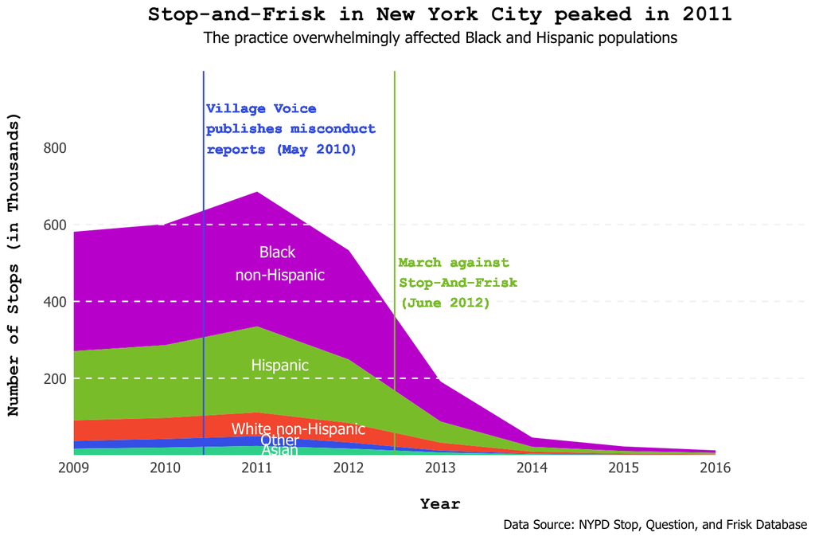

```r
stacked_area <- ggplot(yr, aes(x = year, y=pct, , fill = race_w_hisp.ord))
stacked_area + geom_area()  + scale_fill_manual(values=ncm_colors[-6])+
  xlab("\nYear") + ylab("Number of Stops (in Thousands)\n") +
  scale_x_continuous(breaks=seq(2009,2016,1), expand = c(0,0)) + ncm_theme +
  scale_y_continuous(expand=c(0,0), breaks=seq(200, 800, 200)) + expand_limits(y = c(0, 1000)) +
  labs(title= "Stop-and-Frisk in New York City peaked in 2011",
       subtitle ="The practice overwhelmingly affected Black and Hispanic populations\n",
       caption="Data Source: NYPD Stop, Question, and Frisk Database") +
  geom_vline(xintercept=2010.416, color="#4369EB", linetype="solid") +
  geom_vline(xintercept=2012.5, colour="#8AC437", linetype="solid") +
  annotate("text", x = 2011.25, y = 500, label = "Black \nnon-Hispanic", family=ncm_font2, fontface=1, color="white") +
  annotate("text", x = 2011.25, y = 235, label = "Hispanic", family=ncm_font2, fontface=1, color="white") +
  annotate("text", x = 2011.45, y = 70, label = "White non-Hispanic", family=ncm_font2, fontface=1, color="white") +
  annotate("text", x = 2011.25, y = 40, label = "Other", family=ncm_font2, fontface=1, color="white") +
  annotate("text", x = 2011.25, y = 15, label = "Asian", family=ncm_font2, fontface=1, color="white") +
  geom_hline(yintercept=seq(200, 600, by=200),  colour=ncm_neutral, linetype="dashed") +
  geom_text(aes(x= 2012.55, y = 450, hjust = 0, label="March against\nStop-And-Frisk\n(June 2012)"),  color="#8AC437", family=ncm_font, fontface=2, size=3.5) +
  geom_text(aes(x=2010.45, y = 850, hjust=0, label="Village Voice\npublishes misconduct\nreports (May 2010)"), color="#4369EB", family=ncm_font, fontface=2, size=3.5) + expand_limits(y = c(0, 1000), x = c(2009, 2017))
```

There was much public opposition to stop and frisk, both on the grounds that it was racist and that it did not deter crime. This manifested itself through marches, speeches, demonstrations, and journalism, as well as legal means. By the time the policy was deemed unconstitutional in the end of 2013 the number of stops had already greatly decreased.

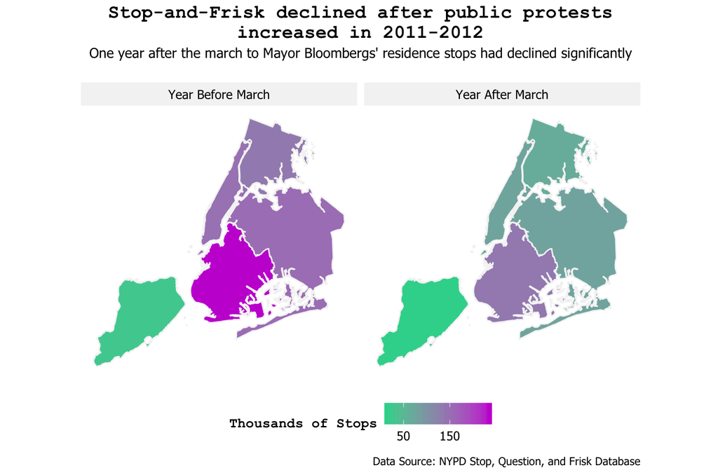

```r
heatmap_all <- ggplot(data = bdf)
heatmap_all + facet_wrap(~fct_rev(before_march))  +
    geom_sf(color=ncm_neutral, aes(fill = num_stops)) + scale_fill_gradient(low=ncm_compliment, high=ncm_highlight,  name="Thousands of Stops", breaks=c(50,150)) + ncm_theme +
  theme(panel.grid.major = element_line(colour = "white"), panel.grid.minor = element_blank(), axis.text = element_blank(), axis.title=element_blank(), legend.position = "bottom") +
  labs(title="Stop-and-Frisk declined after public protests\nincreased in 2011-2012",
       subtitle="One year after the march to Mayor Bloombergs' residence stops had declined significantly\n",
        caption="Data Source: NYPD Stop, Question, and Frisk Database")
```

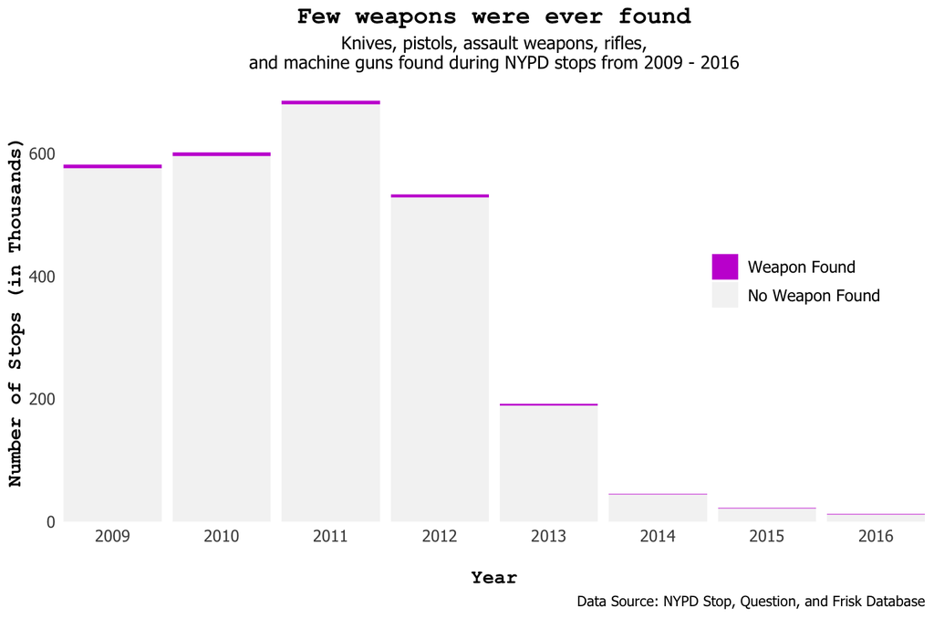

```r
stacked_bar <- ggplot(wf, aes(fill = forcats::fct_rev(weapon_found), y=num_stops, x=year))
stacked_bar + geom_bar(stat="identity") + xlab("\nYear") + ylab("Number of Stops (in Thousands)") + ncm_theme +
  theme(legend.position =c(0.85, 0.6)) +
  scale_x_continuous(breaks=seq(2009,2017,1), expand = c(0,0)) +
  scale_y_continuous(breaks=seq(0,600,200), expand = c(0,0))  +
  scale_fill_manual(values=c(ncm_highlight, ncm_neutral),
    name="",
    breaks=c("Y", "N"),
    labels=c("Weapon Found", "No Weapon Found")) +
 labs(title="Few weapons were ever found",
   subtitle="Knives, pistols, assault weapons, rifles,\nand machine guns found during NYPD stops from 2009 - 2016\n", caption="Data Source: NYPD Stop, Question, and Frisk Database")
```

Stop-and-frisk gave officers the power to detain anyone on the street, and to search them immediately. Previous graphs show that the majority of stops involved black or hispanic individuals. Further, whether a person was frisked once they had already been stopped also varied greatly based on race.

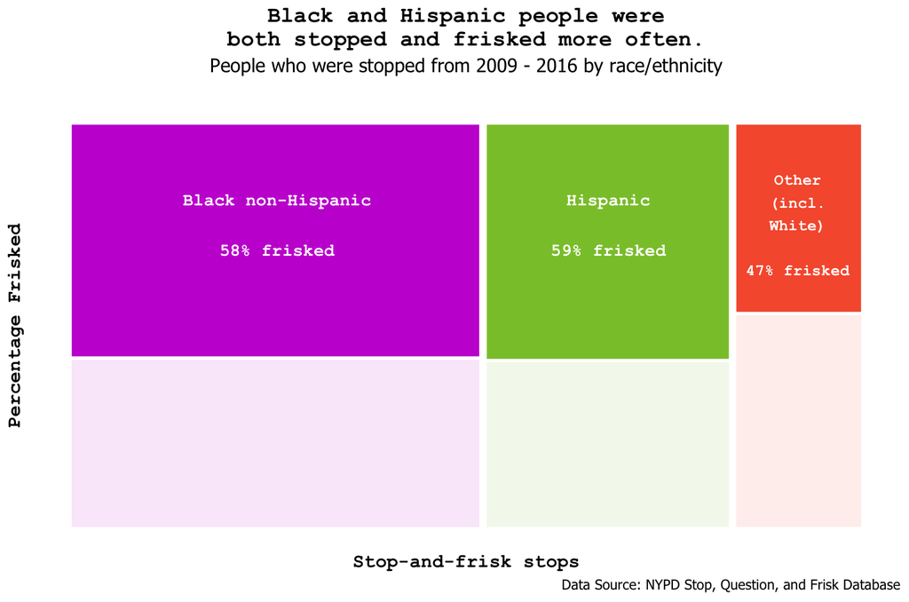

```r
mosaic <- ggplot(data = fr2)
mosaic +
  geom_mosaic(aes(product(race_w_hisp), fill=race_w_hisp,alpha=frisked), na.rm=TRUE) +
  ncm_theme + theme(axis.text = element_blank()) + scale_fill_manual(values=ncm_colors[0:3]) +
  xlab('Stop-and-frisk stops') + ylab("Percentage Frisked") +
  labs(title="Black and Hispanic people were\nboth stopped and frisked more often.",
       subtitle="People who were stopped from 2009 - 2016 by race/ethnicity\n",
       caption="Data Source: NYPD Stop, Question, and Frisk Database") +
  annotate("text", x = .26, y = .75, label = "Black non-Hispanic\n\n58% frisked",family=ncm_font, fontface=2, color="white") +
  annotate("text", x = .68, y = .75, label = "Hispanic\n\n59% frisked", family=ncm_font, fontface=2, color="white") +
  annotate("text", x = .92, y = .75, label = "Other\n(incl.\nWhite)\n\n47% frisked", family=ncm_font, size = 3.5,fontface=2, color="white")
```

### Arrests by and Complaints made to the NYPD

As in any major city, crimes take place in NYC at almost all times of day or night. When a crime is reported the exact time, date, and location of the occurence is noted, along with other information. More crimes happen between about 3pm to 7pm in the evening, and around noon. The number of crimes is also higher in the springtime, from March to June, than at other times of the year.

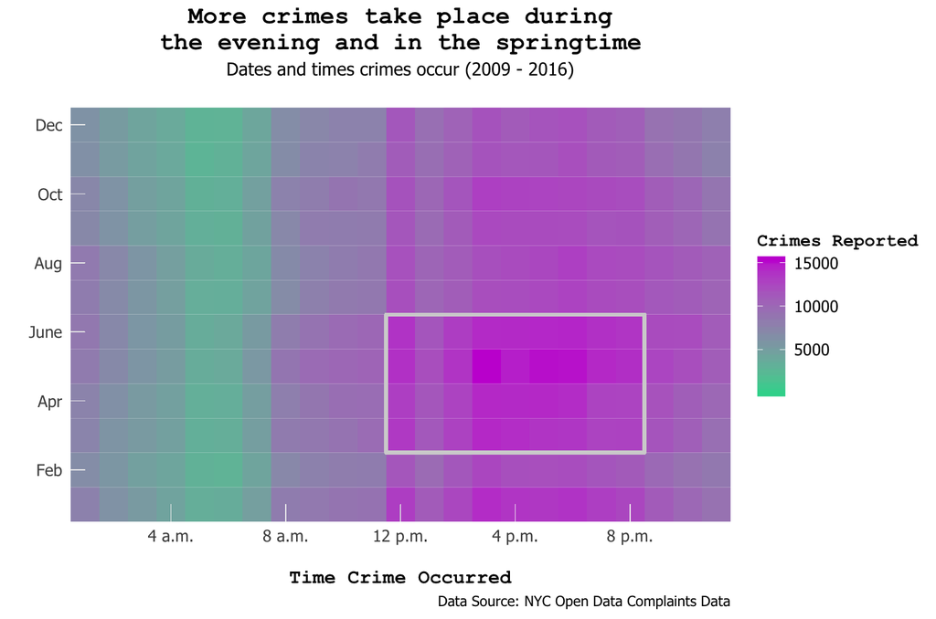

```r
heatmap <- ggplot(ct, aes(Hour, Month))
heatmap + geom_tile(aes(fill = Crimes.Called.In)) +
  scale_fill_gradient(low=ncm_compliment, high=ncm_highlight, name="Crimes Reported") +
  xlab("\nTime Crime Occurred") + ylab("") +
  scale_y_continuous(breaks=c(2,4,6,8,10,12), expand=c(0,0),
      labels=c("Feb", "Apr","June","Aug","Oct", "Dec")) +
  scale_x_continuous(breaks=c(0,4,8,12,16,20), expand=c(0,0),
      labels=c("Midnight", "4 a.m.", "8 a.m.", "12 p.m.", "4 p.m.", "8 p.m.")) +
  labs(title="More crimes take place during\nthe evening and in the springtime",
       subtitle="Dates and times crimes occur (2009 - 2016)\n",
      caption="Data Source: NYC Open Data Complaints Data")  + ncm_theme +
  theme(legend.position = "right") +
  geom_rect(xmin = 11.5, xmax = 20.5, ymin = 2.5, ymax = 6.5, fill=NA, size = 1, color="lightgrey", alpha = .2) +
  geom_segment(x = 4, xend=4, y = 0, yend=1, color=ncm_neutral, size=0.1) +
  geom_segment(x = 8, xend=8, y = 0, yend=1, color=ncm_neutral, size=0.1) +
  geom_segment(x = 12, xend=12, y = 0, yend=1, color=ncm_neutral, size=0.1) +
  geom_segment(x = 16, xend=16, y = 0, yend=1, color=ncm_neutral, size=0.1) +
  geom_segment(x = 20, xend=20, y = 0, yend=1, color=ncm_neutral, size=0.1) +
  geom_segment(x = 0, xend=1, y = 2, yend=2, color=ncm_neutral, size=0.1) +
    geom_segment(x = 0, xend=1, y = 4, yend=4, color=ncm_neutral, size=0.1) +
    geom_segment(x = 0, xend=1, y = 6, yend=6, color=ncm_neutral, size=0.1) +
    geom_segment(x = 0, xend=1, y = 8, yend=8, color=ncm_neutral, size=0.1) +
    geom_segment(x = 0, xend=1, y = 10, yend=10, color=ncm_neutral, size=0.1) +
    geom_segment(x = 0, xend=1, y = 12, yend=12, color=ncm_neutral, size=0.1)
```

The next topic I was interested in was which crimes were the most common in NYC. A question that quickly came up was how to measure that - by the number of complaints or the number of actual arrests. This discrepancy varies greatly from crime to crime. Charges of “harassment 2” make up almost 15% of reported crimes to the NYPD but there are very few arrests for that offense. In contrast “dangerous drugs” account for about 5% of complaints called in but 18% of arrests.

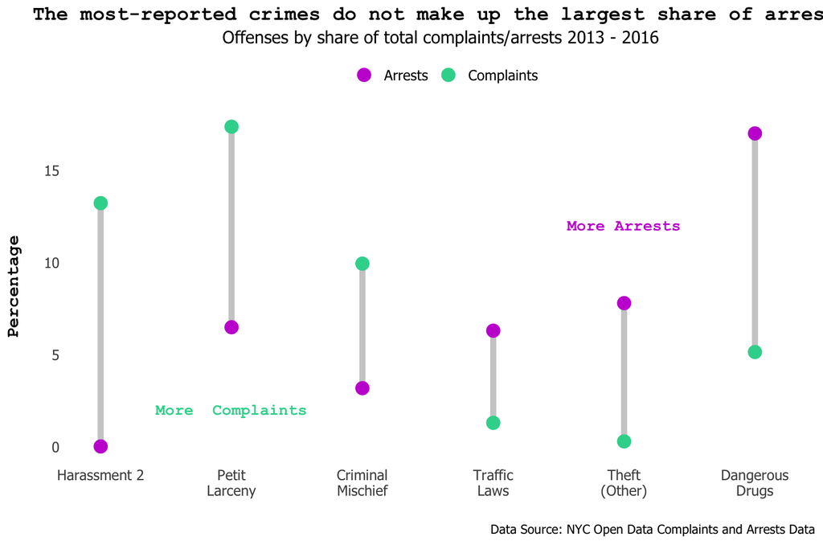

```r
paired_dot <- ggplot(acd, aes(x=rank, y=Percentage, color=type))
paired_dot + geom_line(aes(group=rank), color="darkgrey", alpha=.6, size=2) +
geom_point(alpha=1, size=4) +
  scale_color_manual(values=c("#C732D5", "#32D59B", "#C732D5", "#32D59B"),
                     name="",
                        breaks=c('arrest', 'complaint'),
                        labels=c("Arrests", "Complaints")) +
ncm_theme+ theme(legend.position = "top") +
  scale_x_continuous( breaks=c(1,2,3,4,5,6), labels=c("Harassment 2", "Petit\nLarceny", "Criminal\nMischief", "Traffic\nLaws", "Theft\n(Other)", "Dangerous\nDrugs")) +
  scale_y_continuous(breaks=c(0,5,10,15,20,25)) + xlab("") + ylab("Percentage\n") +
  labs(title="The most-reported crimes do not make up the largest share of arrests",
              subtitle="Offenses by share of total complaints/arrests 2013 - 2016",
       caption="Data Source: NYC Open Data Complaints and Arrests Data") +  expand_limits(x = c(1,6.2)) +
  annotate("text", x = 2, y = 2, label = "More  Complaints",family=ncm_font, fontface=2, color="#32D59B") +
  annotate("text", x =5, y = 12, label = "More Arrests",family=ncm_font, fontface=2, color="#C732D5")
```

Each borough has a very different population, ranging from ~450k in Staten Island to 2.5 million residents in Brooklyn. These sizes makes them comparable to other small cities in their own right. In fact, Brookyln alone has a similar population to Chicago, the third largest city by population in the United States. It is therefore important to look at crime numbers in the context of where they happened. The number of arrests overall has been falling over the past 5 years. When looked at on a per capita basis, Manhattan and the Bronx have the most arrests per one hundred thousand residents.

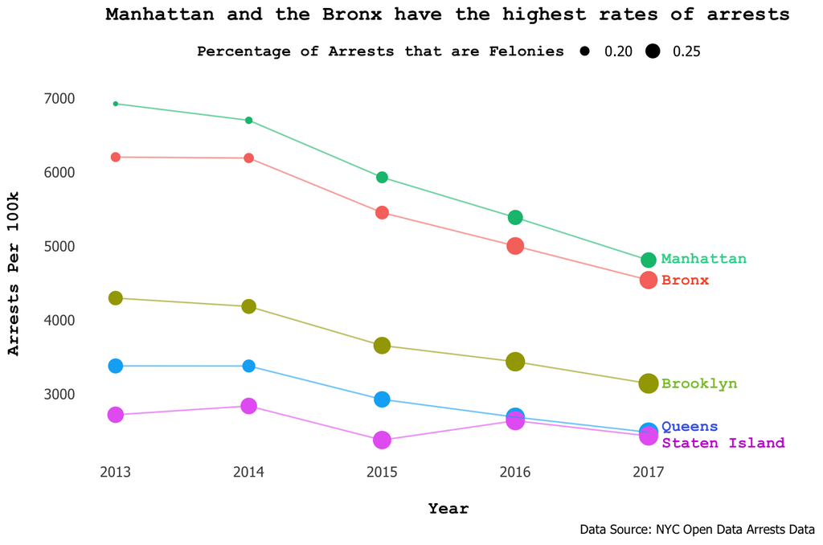

```r
# ???? line

line <- ggplot(ybc, aes(x=YR, y=ARRESTS_PER_100K, color=Borough, size=PERC_FELONIES))
line +
  geom_point(alpha=1)  +
  geom_line(size=0.5, alpha=0.6) +
  scale_fill_manual(values=ncm_colors[5:0]) +
  scale_size_continuous(name="Percentage of Arrests that are Felonies",
                        breaks=c(0.20, 0.25)) +
  scale_color_discrete(guide=FALSE) +
  ylab("Arrests Per 100k\n") +xlab("\nYear") +
  scale_x_continuous(breaks=seq(2013,2017,1))  + ncm_theme +
  theme(legend.position = "top") +
   labs(title="Manhattan and the Bronx have the highest rates of arrests",
        caption="Data Source: NYC Open Data Arrests Data") +
  expand_limits(x = c(2013, 2018)) +
   annotate("text", x = 2017.1, y = 2340, label = "Staten Island",  hjust=0, family=ncm_font, fontface=2, color="#C732D5") +
annotate("text", x = 2017.1, y = 2560, label = "Queens",  hjust=0, family=ncm_font, fontface=2, color="#4369EB") +
annotate("text", x = 2017.1, y = 4830, label = "Manhattan",  hjust=0, family=ncm_font, fontface=2, color="#32D59B") +
annotate("text", x = 2017.1, y = 4540, label = "Bronx", hjust=0, family=ncm_font, fontface=2, color="#F65D3A") +
annotate("text", x = 2017.1, y = 3140, label = "Brooklyn",  hjust=0, family=ncm_font, fontface=2, color="#8AC437") + coord_cartesian(clip="off")
```

[figure not shown]

```r
small_multiple_bars <- ggplot(data = linked_four, aes(x = OFNS_DESC, y = percentage))
small_multiple_bars +
  facet_wrap(~PREM_TYP_DESC) + geom_bar(stat = "identity", color = ncm_neutral, aes(fill=OFNS_DESC)) +
  scale_x_discrete(labels=c("Assault",  "Harrassment", "Petit\nLarceny")) +xlab("") +
  scale_fill_manual(values=ncm_colors) +
  scale_y_continuous(breaks=seq(0, 30, 10)) + ncm_theme +
 # theme(axis.text.x = element_text(size=9)) +
  labs(title="The majority of crimes at places of entertainment are\nassault, harrassment, and petit larceny\n",
        caption="Data Source: NYC Open Data Complaints Data") +ylab("Percent of Total Crimes\n") +
    geom_hline(yintercept=c(10,20),  colour=ncm_neutral, linetype="dashed")
```

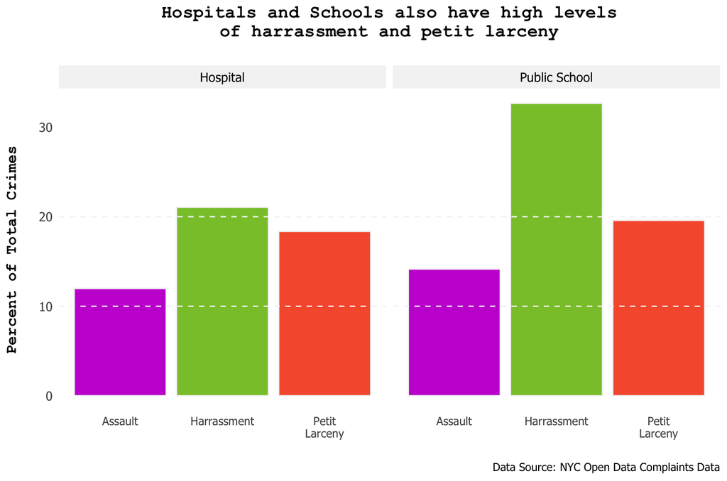

```r
# ??? dashed line? y axis labels? explain why these crimes

ppc_b <- ggplot(data = ppc, aes(x = OFNS_DESC, y = percentage))
ppc_b +
  facet_wrap(~PREM_TYP_DESC) + geom_bar(stat = "identity", color = ncm_neutral, aes(fill=OFNS_DESC)) +
  scale_x_discrete(labels=c("Assault",  "Harrassment", "Petit\nLarceny")) +xlab("") +
  scale_fill_manual(values=ncm_colors) +
  scale_y_continuous(breaks=seq(0, 30, 10)) + ncm_theme +
  theme(axis.text.x = element_text(size=9)) +
  labs(title="Hospitals and Schools also have high levels\nof harrassment and petit larceny\n",
      # subtitle="Places where the most common crimes are assault\nalso have high levels of theft and harassment\n",
        caption="Data Source: NYC Open Data Complaints Data") +ylab("Percent of Total Crimes\n") +
    geom_hline(yintercept=c(10,20),  colour=ncm_neutral, linetype="dashed")
```